# project_perception_writeup

Baohua Zhou

3/4/2018

In this writeup, I will explain the code and the output in the file `project_perception.py`, and will use world 3 as an example to show the outputs at different steps.

## Filtering and RANSAC plane fitting

The image information from the robot’s camera comes in as a ROS message, and in order to apply PCL tools on it, I need to convert the ROS message into PCL data first:

```
    cloud = ros_to_pcl(pcl_msg)
```

After this, since the input image is usually noisy as shown in the following image:

[figure not shown]

Thus, [**statistical outlier filtering**](http://pointclouds.org/documentation/tutorials/statistical_outlier.php) should be applied to remove all those floating noisy points:

```
    outlier_filter = cloud.make_statistical_outlier_filter()
    n_neighbors = 10
    outlier_filter.set_mean_k(n_neighbors)
    thresh_scale = 1.0
    outlier_filter.set_std_dev_mul_thresh(thresh_scale)
    cloud_filtered = outlier_filter.filter()
```

Then, I got something like this:

[figure not shown]

To reduce the dimensionality, [**voxel grid downsampling**](http://pointclouds.org/documentation/tutorials/voxel_grid.php) should be applied (Note that I used 0.01 as the leaf_size here, but this is just for illustration purpose. I used 0.005 to do the object recognition.):

```
    vox = cloud.make_voxel_grid_filter()
    LEAF_SIZE = 0.01
    vox.set_leaf_size(LEAF_SIZE,LEAF_SIZE,LEAF_SIZE)
    cloud_filtered = vox.filter()
```

which will give me the following result:

[figure not shown]

Since I am only interested in the objects on the table, I want to cut the 3d space using [**passthrough filters**](http://docs.pointclouds.org/trunk/classpcl_1_1_pass_through.html) on both ‘z’ and ‘y’ direction:

```
    passthrough = cloud_filtered.make_passthrough_filter()
    filter_axis = 'z'
    passthrough.set_filter_field_name(filter_axis)
    axis_min = 0.6
    axis_max = 1.1
    passthrough.set_filter_limits(axis_min,axis_max)
    cloud_filtered = passthrough.filter()

    passthrough = cloud_filtered.make_passthrough_filter()
    filter_axis = 'y'
    passthrough.set_filter_field_name(filter_axis)
    axis_min = -0.5
    axis_max = 0.5
    passthrough.set_filter_limits(axis_min,axis_max)
    cloud_filtered = passthrough.filter()
```

This will give me:

[figure not shown]

Note that the two small cluters on the two green boxes and the bottom of the table (blocked by the surface of the tabel) are gone if compared with the figure in the previous step.

I am going to separate the table and the objects by performing [**RANSAC plane segmentation**](http://pointclouds.org/documentation/tutorials/planar_segmentation.php):

```
    seg = cloud_filtered.make_segmenter()
    seg.set_model_type(pcl.SACMODEL_PLANE)
    seg.set_method_type(pcl.SAC_RANSAC)
    max_distance = 0.01
    seg.set_distance_threshold(max_distance)
    inliers,coefficients = seg.segment()
```

which will separatet the objects from the table as shown below:

[figure not shown]

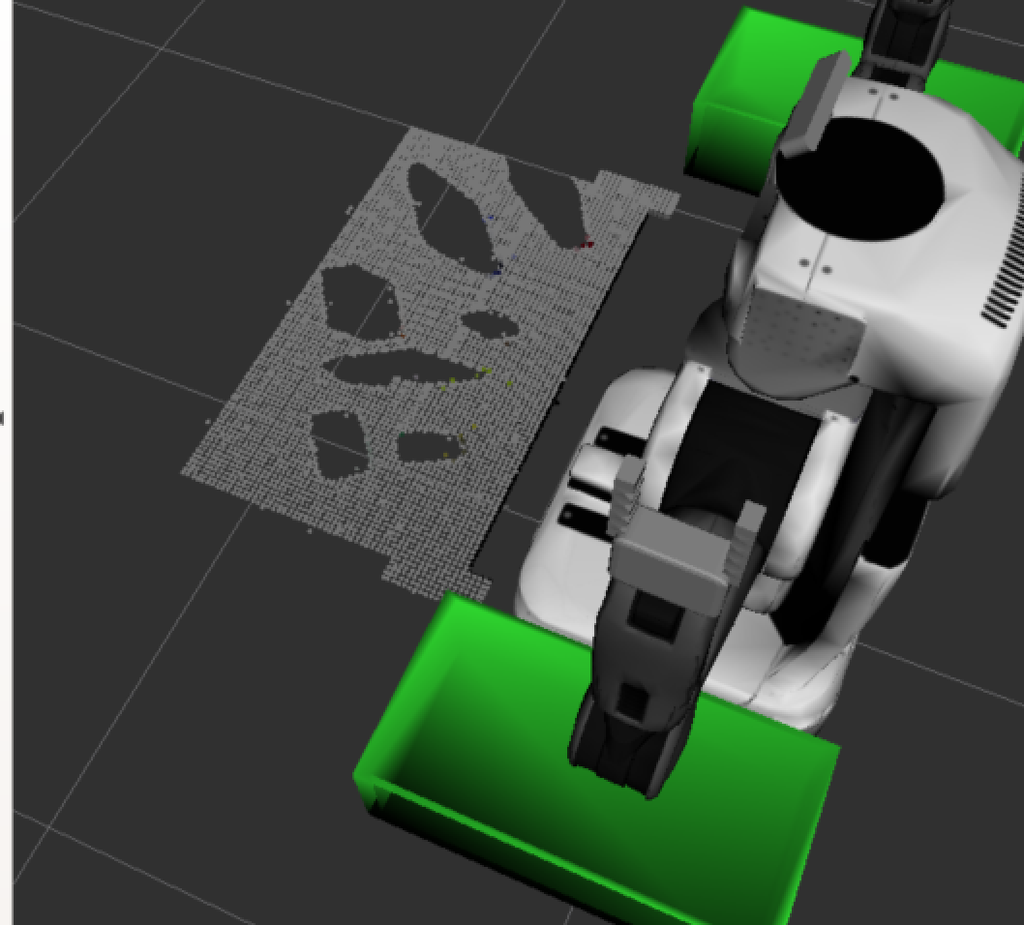

## Clustering

Only position information (white cloud) is used to do the clustering, and the method used here is called [**DBSCAN**](https://en.wikipedia.org/wiki/DBSCAN), which represents Density-Based Spatial Clustering of Applications with Noise.

```
    white_cloud = XYZRGB_to_XYZ(extracted_outliers)
    tree = white_cloud.make_kdtree()
    ec = white_cloud.make_EuclideanClusterExtraction()
    ec.set_ClusterTolerance(0.01)
    ec.set_MinClusterSize(30)
    ec.set_MaxClusterSize(10000)
    ec.set_SearchMethod(tree)
    cluster_indices = ec.Extract()
```

Different colors will be assigned to different clusters:

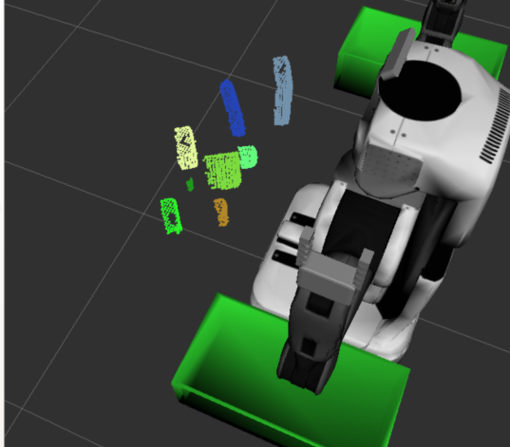

## Object recognition

The feature information used for object recognition are normal historgrams and color histograms. First, I used the function `capture_features.py` to generate a certain amount of the training samples for each obejects in the world, and then use the function `train_svm.py` to get a SVM classifier that is ready to be used for object recognition. To get a sense of the accuracy, I provided the confusion matrix below:

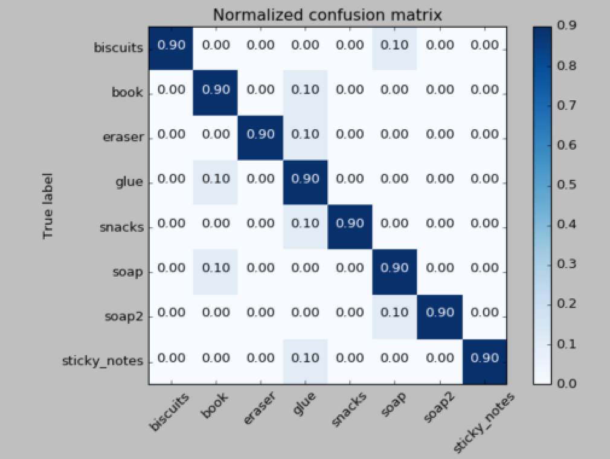

## Final results

For each world, I run the process as discussed above to detect, classify and label objects. I showed the corresponding results as follows:

### World 1

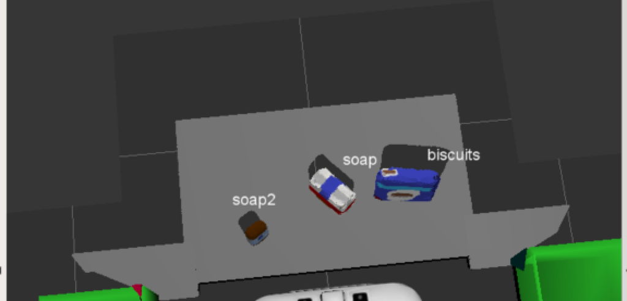

### World 2

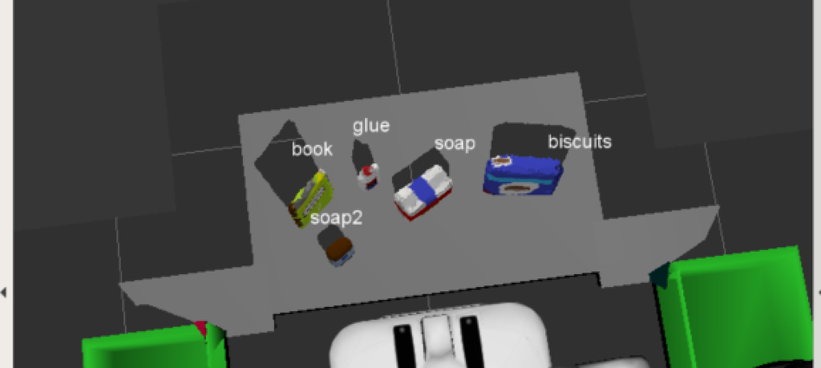

### World 3

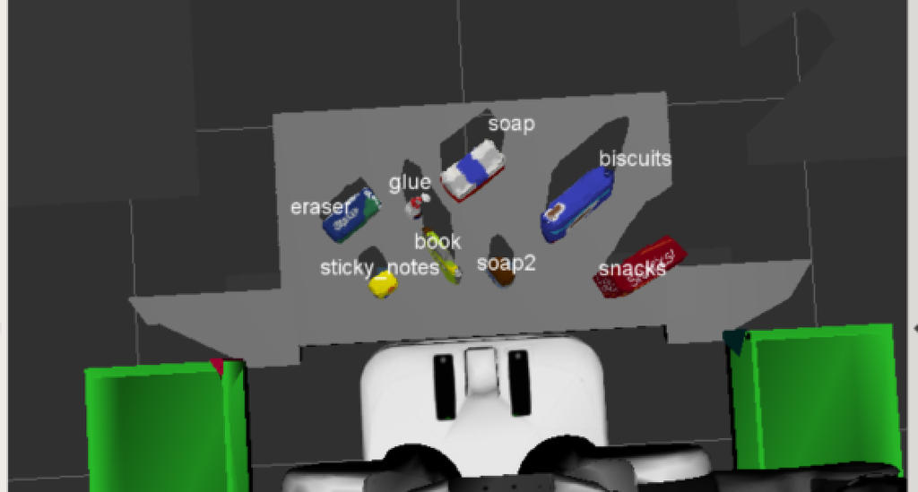

## Discussion

I have implemented filtering, segmentation and clustering algorithms on point cloud data to get the centroid positions of the objects that are supposed to be picked up by the PR2 robot. So far, everything worked smoothly, and I correctly labelled all the objects in the 3 world files. I did not proceed to do the challenge due to time issues. I did not get 100% accuracy during training as shown by the confusion matrix for the world 3 (confusion matrices for world 1 and 2 are not shown). However, but tuning certain parameters in the algorithms, such as leaf_size in downsampling, higher accuracy during training is achievable.